# Kavish property final DD

# Loading packages and import data

In practice loading the packages and the data are in the chuck setup (hidden from output) but here, I’m using as specific chunk.

To load libraries {pacman} is a great tool but some like Hadley Wickam would say that we should avoid it as it will install packages that you don’t necessary want.

```r
if (!require("pacman")) install.packages("pacman")
pacman::p_load(pacman, tidyverse, rio, psych, party)
```

So I’d suggest simply to use for example:

```r
library(tidyverse)
library(here)
library(psych)
```

I see you tried to use Mohd’s code to read data but you forgot the function to read the data file.

```r
(dfdb <- daftdb) %>%
  as_tibble()
```

Instead of using {rio} as Mohd, I would use a function from the {readr} package

```r
daftdb <- here("data/daftdb.rds") %>% read_rds

dfdb <- daftdb # just to match with you code but as.tibble is not necessary
```

# Convert price as numeric

I see you did some tests:

```r
# gsub () is used to substitute specific text from a string with other text,
# and as.numeric () can coerce a variable to numeric.
# gsub(pattern, replacement, x, ignore.case = FALSE)

#testdf <- dfdb %>%
#  filter(index == 1 | index == 284 | index == 259) %>%
#  print()

#gsub("Terraced","Roof",testdf$structure, ignore.case = T)

class(dfdb$price)
```

```
## [1] "character"
```

Indeed price is a character variable and not numeric, that’s the biggest challenge.

```r
#replaced the string and trimmed--------------------------------------------------------
dfdb$price <- str_replace_all(dfdb$price, "[a-z,A-Z,:]","") #"[a-z,A-Z]",""

dfdb$price <- str_trim(dfdb$price) #removed whitespaces

#euro sign removed-------------------------------------------------------------------
dfdb$price <- str_sub(dfdb$price,2)

#replaced empty spaces with 0--------------------------------------------------------
dfdb$price <- str_replace_all(dfdb$price, "^$", "0")

#testdf$price2 <- gsub("^$", "0", testdf$price2) - This would work too

#commas removed- not needed ---------------------------------------------------------
#testdf$price2 <- str_replace(testdf$price2, ",","")

#conversion time-------------------------------------------------------------------
dfdb$price <- as.double(dfdb$price)
class(dfdb$price) #successful
```

```
## [1] "numeric"
```

```r
summary(dfdb$price)
```

```
##    Min. 1st Qu.  Median    Mean 3rd Qu.    Max.
##       0  330000  395000  478906  530000 3600000
```

The use of regex to extract the numeric price is excellent!

Be careful with the style of your code, the ‘=’ for object assignment is not advised and try to use a space after a comma. For more details about the coding style you could have a look at https://style.tidyverse.org/index.html

Your approach is to remove all the letters and whitespaces, but you could also have kept only the numeric values with:

```r
stringr::str_extract(daftdb$price[1], "[0-9]+(?:,[0-9]+)?")
```

```
## [1] "350,000"
```

But there is a perfect function in the {readr} package called `parse_number()`

```r
readr::parse_number(daftdb$price[1])
```

```
## [1] 350000
```

# Visualisation

I see you used base R for your boxplot.

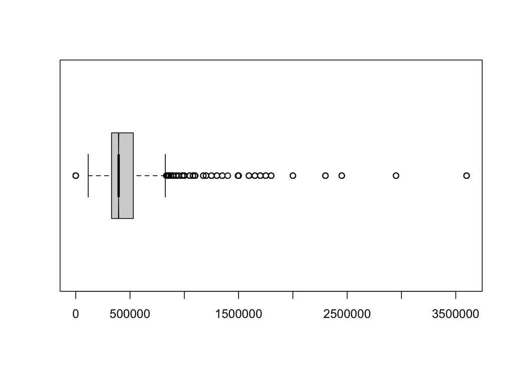

```r
#Boxplot of price-------------------------------------------------------------------
boxplot(dfdb$price, notch = T, horizontal = T)
```

This is perfectly fine but a ggplot approach could be nice as well:

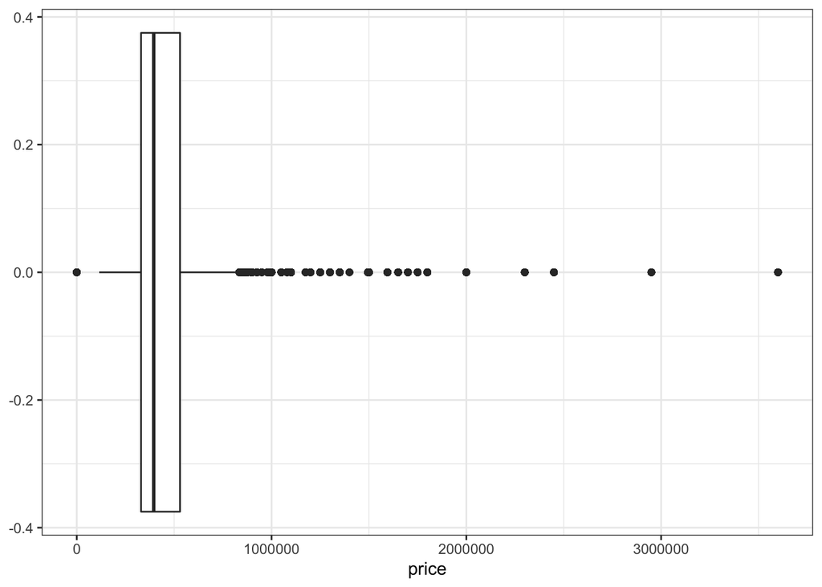

```r
ggplot(dfdb, aes(price)) +
  geom_boxplot() +
  theme_bw()
```